# Diagnosing the Tier-1 De-biased Estimate (DINA, effect re-ranking)

Per-resample component decomposition, over-extension & outlier checks, IJ-variance attribution

Author

Larry F. León

Published

June 13, 2026

```r
# Run AFTER devtools::install() (the bootstrap spawns workers that see only the
# installed package).  Mirrors the DGM + DINA configuration of
# dina1_multiplier-resampling_vs_bootstrap_debias__simulation.qmd.
library(forestsearch)
library(survival)
library(data.table)
library(ggplot2)
library(future)
has_patch <- requireNamespace("patchwork", quietly = TRUE)
if (has_patch) library(patchwork)
library(foreach)
library(doFuture)

set.seed(20260613)

`%||%` <- function(a, b) if (is.null(a) || length(a) == 0 || all(is.na(a))) b else a

# ---- DGM knobs (León M1 cell; identical to the simulation) --------------
dgm_model      <- "alt"
target_hr_harm <- 2.0
n_sample       <- 700L
analysis_time  <- 84
cens_adjust    <- log(1.5)
n_super        <- 5000L
seed_base      <- 8316951L

# ---- DINA / forestsearch config (identical to the simulation) -----------
subgroup_method       <- "dina"
dina_select_statistic <- "effect"
dina_args             <- list()
sg_focus              <- "eff"
selection_rule        <- "neighborhood"
hr_threshold          <- 1.25
hr_consistency        <- 1.0
pconsistency          <- 0.90
n_min                 <- NULL
consistency_method    <- "resample"

# ---- diagnostic knobs ---------------------------------------------------
DIAG_NB    <- 400L                                   # Tier-1 resamples (match the sim)
GATE_DRAWS <- 2000L
n_workers  <- max(1L, parallel::detectCores(logical = FALSE) - 1L)
max_seed_tries <- 25L                                # find a replicate where DINA detects + Tier-1 returns H2

# ---- comprehensive (cross-replicate) diagnostic knobs -------------------
RUN_CROSS_REP <- TRUE     # SD-calibration / coverage / decomposition across replicates
n_diag_reps   <- 500L     # replicates for the cross-replicate section (prod: 500 -> 1000)

outcome_name <- "y_sim"; event_name <- "event_sim"
treat_name   <- "treat_sim"; id_name <- "id"; harm_col <- "flag_harm"
confounders_base <- c("er", "age", "meno", "pgr", "nodes", "size", "grade")
z975 <- qnorm(0.975)
```

This document decomposes the **Tier-1** (full-bootstrap, León Eq. 7) de-biased estimate for a single representative DINA replicate into the two resampling discrepancies it subtracts, and checks whether the gap to **Tier-2** (the refit-free gate) and the inflated IJ standard error are driven by a healthy distribution or by over-extended / degenerate re-selected subgroups. The identities used (working/log scale, per resample $b$):

$$\underbrace{\eta^{*}_b(\hat H^{*}_b)}_{\text{selection optimism}} = \hat\beta(\hat H) - \texttt{H\_biasadj\_1}_b,
\qquad
\underbrace{\eta^{*}_b(\hat H)}_{\text{fixed-subgroup term}} = \texttt{H\_biasadj\_1}_b - \texttt{H\_biasadj\_2}_b,$$

with $\tilde\beta(\hat H) = \overline{\texttt{H\_biasadj\_2}}$ and the IJ per-draw residual $r_b = \texttt{H\_biasadj\_2}_b - \tilde\beta(\hat H)$. The naive $\hat\beta(\hat H)$ is `log(H_estimates$H0)`, and the re-selected subgroup’s effect on the bootstrap sample is `Hstar_star = log(hr_sg)`.

# 1 Build DGM and run one representative replicate

```r
k_inter <- calibrate_k_inter(target_hr_harm = target_hr_harm, model = dgm_model, use_ahr = FALSE)
dgm <- compute_dgm_cde(setup_gbsg_dgm(model = dgm_model, k_inter = k_inter,
                                      n_super = n_super, seed = seed_base))

run_one <- function(sim_id) {
  df <- simulate_from_dgm(dgm, n = n_sample, analysis_time = analysis_time,
                          cens_adjust = cens_adjust, seed = seed_base + sim_id)
  df[[id_name]] <- seq_len(nrow(df))
  confs <- intersect(confounders_base, names(df))

  fs.est <- tryCatch(forestsearch(
    df.analysis = df, outcome.name = outcome_name, event.name = event_name,
    treat.name = treat_name, id.name = id_name, flag_harm.name = harm_col,
    confounders.name = confs, is.RCT = TRUE, seedit = seed_base + sim_id, quiet = TRUE,
    sg_focus = sg_focus, subgroup_method = subgroup_method,
    hr.threshold = hr_threshold, hr.consistency = hr_consistency,
    pconsistency.threshold = pconsistency, n.min = n_min, selection_rule = selection_rule,
    parallel_args = list(plan = "multisession", workers = n_workers),
    debias_gate = TRUE,
    debias_gate_args = list(ci_method = "ij", draws = GATE_DRAWS, include_complement = TRUE),
    dina_select_statistic = dina_select_statistic, dina_args = dina_args
  ), error = function(e) NULL)
  plan("sequential")
  if (is.null(fs.est) || is.null(fs.est$sg.harm)) return(NULL)

  boot <- tryCatch(forestsearch_bootstrap_dofuture(
    fs.est, nb_boots = DIAG_NB, seed = seed_base + sim_id,
    parallel_args = list(plan = "multisession", workers = n_workers)
  ), error = function(e) NULL)
  plan("sequential")
  if (is.null(boot) || is.null(boot$H_estimates)) return(NULL)

  list(df = df, fs.est = fs.est, boot = boot, sim_id = sim_id)
}

fit <- NULL
for (s in seq_len(max_seed_tries)) {
  fit <- run_one(s)
  if (!is.null(fit)) break
}
```

```
Bootstrap parallel config: Using user-provided settings
```

```
System max cores available: 14
```

```
Bootstrap will use: 13 workers with 'multisession' plan
```

```
Bootstrap iteration 1/400
```

```
Bootstrap iteration 10/400
```

```
Bootstrap iteration 50/400
```

```
Bootstrap iteration 100/400
```

```
Bootstrap iteration 250/400
```

```
Bootstrap iteration 400/400
```

```r
stopifnot("No detected DINA replicate with a Tier-1 H2 in max_seed_tries." = !is.null(fit))
cat(sprintf("Using replicate sim_id = %d (DINA, effect re-ranking), nb_boots = %d.\n",
            fit$sim_id, DIAG_NB))
```

```
Using replicate sim_id = 6 (DINA, effect re-ranking), nb_boots = 400.
```

# 2 Reconstruct per-resample components

```r
# Reusable: reconstruct the four per-resample fits + IJ residual from any
# forestsearch_bootstrap_dofuture() object, on the estimator's working scale.
tier1_components <- function(boot) {
  stopifnot(!is.null(boot$results), !is.null(boot$H_estimates))
  res <- data.table::copy(data.table::as.data.table(boot$results))
  ratio <- identical(boot$outcome_type, "survival") ||
    (!is.null(boot$effect_measure) && boot$effect_measure %in% c("OR", "RR", "IRR", "HR"))
  H_obs_log <- if (ratio) log(boot$H_estimates$H0) else boot$H_estimates$H0

  res[, eta_sel    := H_obs_log - H_biasadj_1]                 # selection optimism  eta*_b(Hhat*_b)
  res[, eta_fix    := H_biasadj_1 - H_biasadj_2]               # fixed-subgroup term eta*_b(Hhat)
  res[, Hstar_star := if (ratio) log(hr_sg) else hr_sg]        # re-selected effect | bootstrap data
  res[, Hstar_obs  := Hstar_star - eta_sel]                    # re-selected effect | original data
  res[, H_star     := H_obs_log + eta_fix]                     # original subgroup | bootstrap data
  betatilde <- mean(res$H_biasadj_2, na.rm = TRUE)
  res[, r_b := H_biasadj_2 - betatilde]                        # IJ per-draw residual
  attr(res, "H_obs_log") <- H_obs_log
  attr(res, "betatilde") <- betatilde
  attr(res, "ratio")     <- ratio
  res[]
}

comp <- tier1_components(fit$boot)
H_obs_log <- attr(comp, "H_obs_log"); betatilde <- attr(comp, "betatilde")
ratio <- attr(comp, "ratio")
ex <- function(z) if (ratio) exp(z) else z   # working -> reported scale

# Tier-2 (gate) + oracle on the same replicate, for the comparison.
g <- fit$fs.est$debias_gate
t2_est <- g$debiased$est; t2_lo <- g$debiased$lower; t2_hi <- g$debiased$upper
t2_se_ij <- g$debiased$se_ij %||% NA_real_
naive_est <- g$naive$est

ora <- local({
  d <- fit$df[fit$df[[harm_col]] == 1L, , drop = FALSE]
  if (sum(d[[event_name]]) < 5L || length(unique(d[[treat_name]])) < 2L) return(NA_real_)
  fml <- as.formula(sprintf("Surv(%s, %s) ~ %s", outcome_name, event_name, treat_name))
  f <- tryCatch(coxph(fml, data = d), error = function(e) NULL)
  if (is.null(f)) NA_real_ else exp(unname(coef(f)[1]))
})

n_eval <- sum(is.finite(comp$H_biasadj_2))
cat(sprintf("Evaluable resamples: %d of %d\n", n_eval, nrow(comp)))
```

```
Evaluable resamples: 375 of 400
```

## 2.1 Decomposition of the de-biased estimate

```r
bias_sel <- mean(comp$eta_sel, na.rm = TRUE)
bias_fix <- mean(comp$eta_fix, na.rm = TRUE)
se_ij_t1 <- fit$boot$H_estimates$sdH2

decomp <- data.frame(
  Quantity = c("naive  beta_hat(H)",
               "  - bias_fix  (mean fixed-subgroup term)",
               "  - bias_sel  (mean selection optimism)",
               "= Tier-1  beta_tilde(H)",
               "Tier-2 gate  (debiased)",
               "oracle (true H)"),
  `log scale` = c(H_obs_log, -bias_fix, -bias_sel, betatilde,
                  log(t2_est), if (is.finite(ora)) log(ora) else NA_real_),
  `reported (HR)` = c(ex(H_obs_log), NA, NA, ex(betatilde), t2_est, ora),
  check.names = FALSE
)
knitr::kable(decomp, digits = 3,
             caption = sprintf("Tier-1 de-biasing decomposition (replicate %d). bias_sel + bias_fix = %.3f on the log scale; Tier-1 IJ SE = %.3f, Tier-2 IJ SE = %.3f.",
                               fit$sim_id, bias_sel + bias_fix, se_ij_t1, t2_se_ij))
```

Tier-1 de-biasing decomposition (replicate 6). bias_sel + bias_fix = 0.393 on the log scale; Tier-1 IJ SE = 0.718, Tier-2 IJ SE = 0.480.

| Quantity | log scale | reported (HR) |
| --- | --- | --- |
| naive beta_hat(H) | 1.025 | 2.786 |
| - bias_fix (mean fixed-subgroup term) | -0.062 | NA |
| - bias_sel (mean selection optimism) | -0.331 | NA |
| = Tier-1 beta_tilde(H) | 0.631 | 1.880 |
| Tier-2 gate (debiased) | 0.915 | 2.497 |
| oracle (true H) | 0.940 | 2.560 |

The mechanical reading: Tier-1 sits below Tier-2 by whatever extra optimism the **re-fitted family** injects into `bias_sel` (Tier-2 only removes within-family optimism). If `bias_sel` is large *and* the histograms below are skewed with a heavy left tail in `Hstar_star`, the gap is being manufactured by a minority of resamples, not by the bulk.

## 2.2 Component distributions and the optimism that drives the gap

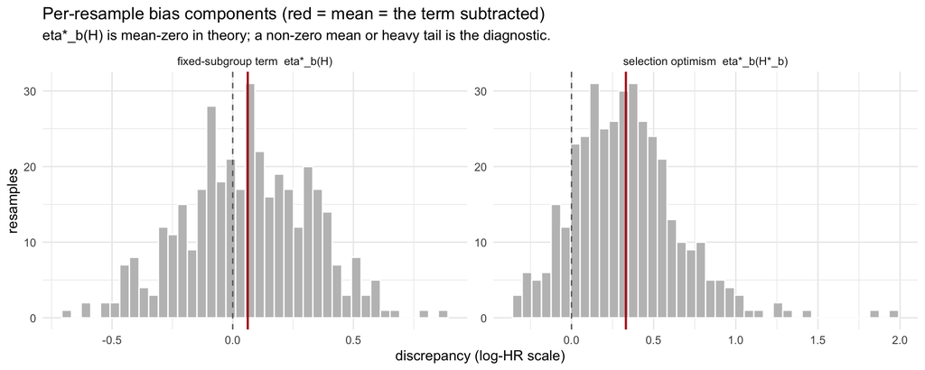

```r
long <- rbind(
  data.frame(term = "selection optimism  eta*_b(H*_b)", value = comp$eta_sel),
  data.frame(term = "fixed-subgroup term  eta*_b(H)",   value = comp$eta_fix)
)
means <- data.frame(
  term = c("selection optimism  eta*_b(H*_b)", "fixed-subgroup term  eta*_b(H)"),
  m = c(bias_sel, bias_fix))

ggplot(subset(long, is.finite(value)), aes(value)) +
  geom_histogram(bins = 40, fill = "grey75", colour = "white") +
  geom_vline(data = means, aes(xintercept = m), colour = "firebrick", linewidth = 0.8) +
  geom_vline(xintercept = 0, linetype = 2, colour = "grey40") +
  facet_wrap(~ term, scales = "free") +
  labs(x = "discrepancy (log-HR scale)", y = "resamples",
       title = "Per-resample bias components (red = mean = the term subtracted)",
       subtitle = "eta*_b(H) is mean-zero in theory; a non-zero mean or heavy tail is the diagnostic.") +
  theme_minimal(base_size = 11)
```

## 2.3 Re-selected subgroup size: over-extension check

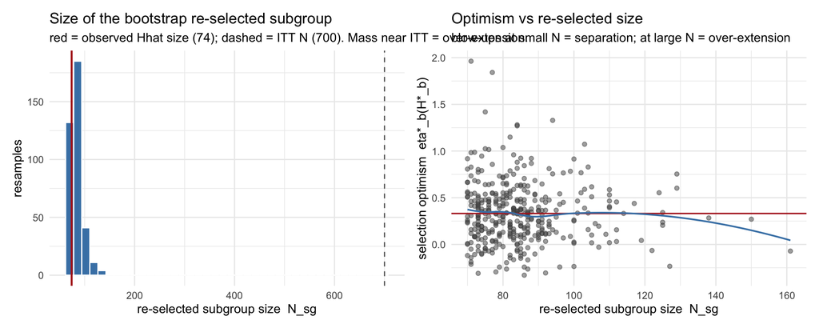

```r
N_itt <- nrow(fit$df)
n_obs_sg <- sum(fit$fs.est$grp.consistency$sg.harm.id == 1L, na.rm = TRUE)

p_size <- ggplot(subset(comp, is.finite(N_sg)), aes(N_sg)) +
  geom_histogram(bins = 40, fill = "steelblue", colour = "white") +
  geom_vline(xintercept = n_obs_sg, colour = "firebrick", linewidth = 0.8) +
  geom_vline(xintercept = N_itt, linetype = 2, colour = "grey40") +
  labs(x = "re-selected subgroup size  N_sg", y = "resamples",
       title = "Size of the bootstrap re-selected subgroup",
       subtitle = sprintf("red = observed Hhat size (%d); dashed = ITT N (%d). Mass near ITT = over-extension.",
                          n_obs_sg, N_itt)) +
  theme_minimal(base_size = 11)

p_scatter <- ggplot(subset(comp, is.finite(N_sg) & is.finite(eta_sel)),
                    aes(N_sg, eta_sel)) +
  geom_point(alpha = 0.5, colour = "grey30") +
  geom_hline(yintercept = bias_sel, colour = "firebrick", linewidth = 0.6) +
  geom_smooth(method = "loess", se = FALSE, colour = "steelblue", linewidth = 0.7) +
  labs(x = "re-selected subgroup size  N_sg", y = "selection optimism  eta*_b(H*_b)",
       title = "Optimism vs re-selected size",
       subtitle = "blow-ups at small N = separation; at large N = over-extension") +
  theme_minimal(base_size = 11)

if (has_patch) p_size + p_scatter else { print(p_size); print(p_scatter) }
```

## 2.4 Outliers and their leverage on the estimate and the variance

```r
cc <- comp[is.finite(H_biasadj_2)]
Q  <- quantile(cc$H_biasadj_2, c(.25, .75), na.rm = TRUE)
iqr <- diff(Q); lo_f <- Q[1] - 1.5 * iqr; hi_f <- Q[2] + 1.5 * iqr
cc[, outlier := H_biasadj_2 < lo_f | H_biasadj_2 > hi_f]
# Leverage on the mean (point estimate) and on the IJ variance:
cc[, lev_mean := (H_biasadj_2 - betatilde) / n_eval]   # contribution to beta_tilde
cc[, var_share := r_b^2 / sum(r_b^2, na.rm = TRUE)]    # share of sum r_b^2 (drives sigma_B^2 / V_hat)

cat(sprintf("IQR-fence outliers in H_biasadj_2: %d of %d evaluable resamples.\n",
            sum(cc$outlier), nrow(cc)))
```

```
IQR-fence outliers in H_biasadj_2: 3 of 375 evaluable resamples.
```

```r
ob <- head(cc[order(-abs(r_b))], 10L)
knitr::kable(
  ob[, .(boot_id, N_sg,
         Hstar_star = round(ex(Hstar_star), 2),    # re-selected effect (HR scale)
         eta_sel = round(eta_sel, 3), eta_fix = round(eta_fix, 3),
         H2 = round(H_biasadj_2, 3), r_b = round(r_b, 3),
         var_share = round(var_share, 3))],
  caption = "Top 10 resamples by |IJ residual| — the ones most inflating sigma_B^2 / V_hat. Large var_share concentrated in a few rows = an outlier-driven SE.")
```

Top 10 resamples by |IJ residual| — the ones most inflating sigma_B^2 / V_hat. Large var_share concentrated in a few rows = an outlier-driven SE.

| boot_id | N_sg | Hstar_star | eta_sel | eta_fix | H2 | r_b | var_share |
| --- | --- | --- | --- | --- | --- | --- | --- |
| 169 | 77 | 7.66 | 1.841 | 0.779 | -1.596 | -2.227 | 0.055 |
| 218 | 71 | 3.69 | 1.962 | 0.105 | -1.042 | -1.674 | 0.031 |
| 135 | 74 | 6.96 | 0.946 | 0.872 | -0.793 | -1.424 | 0.023 |
| 206 | 100 | 1.96 | -0.236 | -0.611 | 1.872 | 1.240 | 0.017 |
| 175 | 75 | 3.31 | 1.419 | 0.118 | -0.512 | -1.143 | 0.015 |
| 264 | 86 | 1.68 | -0.329 | -0.398 | 1.753 | 1.121 | 0.014 |
| 267 | 87 | 2.12 | -0.264 | -0.457 | 1.746 | 1.115 | 0.014 |
| 24 | 79 | 2.11 | -0.243 | -0.469 | 1.736 | 1.105 | 0.014 |
| 92 | 84 | 4.40 | 1.270 | 0.217 | -0.462 | -1.093 | 0.013 |
| 198 | 96 | 1.96 | -0.242 | -0.445 | 1.712 | 1.081 | 0.013 |

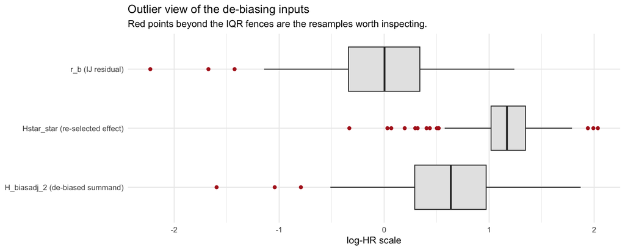

```r
boxdat <- rbind(
  data.frame(q = "H_biasadj_2 (de-biased summand)", v = comp$H_biasadj_2),
  data.frame(q = "Hstar_star (re-selected effect)", v = comp$Hstar_star),
  data.frame(q = "r_b (IJ residual)",               v = comp$r_b)
)
ggplot(subset(boxdat, is.finite(v)), aes(q, v)) +
  geom_boxplot(outlier.colour = "firebrick", fill = "grey90") +
  coord_flip() +
  labs(x = NULL, y = "log-HR scale",
       title = "Outlier view of the de-biasing inputs",
       subtitle = "Red points beyond the IQR fences are the resamples worth inspecting.") +
  theme_minimal(base_size = 11)
```

## 2.5 IJ variance attribution by subject

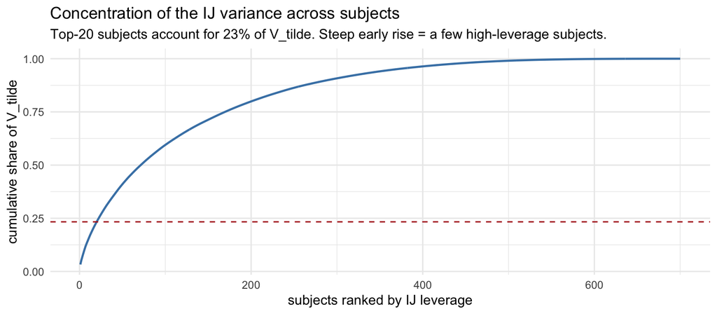

```r
# Replicate get_targetEst's cov_i = mean((K_bi - mean K_i) * r_b) per subject,
# from the SAME multiplicity matrix the estimate used (defensively realigned).
Y <- fit$boot$Ystar_mat
if (nrow(Y) != nrow(comp) && !is.null(comp$boot_id)) Y <- Y[comp$boot_id, , drop = FALSE]
rb <- comp$H_biasadj_2 - betatilde
cov_i <- apply(Y, 2, function(col) mean((col - mean(col, na.rm = TRUE)) * rb, na.rm = TRUE))
Vt <- sum(cov_i^2, na.rm = TRUE)
share <- sort(cov_i^2 / Vt, decreasing = TRUE)
top20 <- sum(head(share, 20))

ggplot(data.frame(rank = seq_along(share), cum = cumsum(share)),
       aes(rank, cum)) +
  geom_line(colour = "steelblue", linewidth = 0.8) +
  geom_hline(yintercept = top20, linetype = 2, colour = "firebrick") +
  labs(x = "subjects ranked by IJ leverage", y = "cumulative share of V_tilde",
       title = "Concentration of the IJ variance across subjects",
       subtitle = sprintf("Top-20 subjects account for %.0f%% of V_tilde. Steep early rise = a few high-leverage subjects.",
                          100 * top20)) +
  theme_minimal(base_size = 11)
```

# 3 Comprehensive cross-replicate diagnostics

The single-replicate views above show *mechanism*; the SD over-estimation you observed (empirical ≈ 0.51 vs mean estimated ≈ 0.71) is a **cross-replicate** property, so this section runs `n_diag_reps` independent replicates (outer loop parallel; inner `forestsearch()`/bootstrap forced sequential to avoid nested parallelism) and compares, for Tier-1 and Tier-2: the empirical SD of the point estimate against the mean estimated SD, oracle coverage, the per-replicate bias decomposition, and whether over-extended re-selections drive the gap. Each tier’s working-scale SE is derived uniformly from its own CI, `sd_log = (log(hi) - log(lo)) / (2 z)`, which reproduces `sdH2` exactly for Tier-1 and puts both tiers on identical footing.

```r
one_rep_record <- function(sim_id) {
  na_rec <- data.frame(
    sim_id = sim_id, detected = 0L, gate_ok = 0L,
    naive_est = NA_real_, naive_lo = NA_real_, naive_hi = NA_real_,
    t1_est = NA_real_, t1_lo = NA_real_, t1_hi = NA_real_,
    t2_est = NA_real_, t2_lo = NA_real_, t2_hi = NA_real_,
    oracle_hr = NA_real_, bias_sel = NA_real_, bias_fix = NA_real_,
    n_sel = NA_integer_, med_Nsg = NA_real_, max_Nsg = NA_real_,
    n_eval = NA_integer_, N_rep = NA_integer_)

  df <- tryCatch(simulate_from_dgm(dgm, n = n_sample, analysis_time = analysis_time,
                                   cens_adjust = cens_adjust, seed = seed_base + sim_id),
                 error = function(e) NULL)
  if (is.null(df)) return(na_rec)
  df[[id_name]] <- seq_len(nrow(df)); confs <- intersect(confounders_base, names(df))
  na_rec$N_rep <- nrow(df)

  fs.est <- tryCatch(forestsearch(
    df.analysis = df, outcome.name = outcome_name, event.name = event_name,
    treat.name = treat_name, id.name = id_name, flag_harm.name = harm_col,
    confounders.name = confs, is.RCT = TRUE, seedit = seed_base + sim_id, quiet = TRUE,
    sg_focus = sg_focus, subgroup_method = subgroup_method,
    hr.threshold = hr_threshold, hr.consistency = hr_consistency,
    pconsistency.threshold = pconsistency, n.min = n_min, selection_rule = selection_rule,
    parallel_args = list(plan = "sequential"),
    debias_gate = TRUE,
    debias_gate_args = list(ci_method = "ij", draws = GATE_DRAWS, include_complement = TRUE),
    dina_select_statistic = dina_select_statistic, dina_args = dina_args
  ), error = function(e) NULL)
  if (is.null(fs.est) || is.null(fs.est$sg.harm)) return(na_rec)
  na_rec$detected <- 1L
  na_rec$n_sel <- sum(fs.est$grp.consistency$sg.harm.id == 1L, na.rm = TRUE)
  g <- fs.est$debias_gate
  if (!is.null(g)) {
    na_rec$gate_ok <- 1L
    na_rec$t2_est <- g$debiased$est; na_rec$t2_lo <- g$debiased$lower; na_rec$t2_hi <- g$debiased$upper
  }

  boot <- tryCatch(forestsearch_bootstrap_dofuture(
    fs.est, nb_boots = DIAG_NB, seed = seed_base + sim_id,
    parallel_args = list(plan = "sequential")), error = function(e) NULL)
  if (!is.null(boot) && !is.null(boot$H_estimates)) {
    he <- boot$H_estimates; res <- boot$results
    H_obs_log <- log(he$H0)
    na_rec$naive_est <- he$H0; na_rec$naive_lo <- he$H0_lower; na_rec$naive_hi <- he$H0_upper
    na_rec$t1_est <- he$H2;    na_rec$t1_lo   <- he$H2_lower; na_rec$t1_hi   <- he$H2_upper
    na_rec$bias_sel <- mean(H_obs_log - res$H_biasadj_1, na.rm = TRUE)
    na_rec$bias_fix <- mean(res$H_biasadj_1 - res$H_biasadj_2, na.rm = TRUE)
    na_rec$n_eval   <- sum(is.finite(res$H_biasadj_2))
    na_rec$med_Nsg  <- stats::median(res$N_sg, na.rm = TRUE)
    na_rec$max_Nsg  <- suppressWarnings(max(res$N_sg, na.rm = TRUE))
  }

  d <- df[df[[harm_col]] == 1L, , drop = FALSE]
  if (sum(d[[event_name]]) >= 5L && length(unique(d[[treat_name]])) >= 2L) {
    fml <- as.formula(sprintf("Surv(%s, %s) ~ %s", outcome_name, event_name, treat_name))
    f <- tryCatch(coxph(fml, data = d), error = function(e) NULL)
    if (!is.null(f)) na_rec$oracle_hr <- exp(unname(coef(f)[1]))
  }
  na_rec
}

plan(multisession, workers = n_workers)
rec_list <- foreach(s = seq_len(n_diag_reps),
                    .options.future = list(seed = TRUE,
                      packages = c("forestsearch", "survival", "data.table"))) %dofuture%
  one_rep_record(s)
plan(sequential)

cross <- data.table::rbindlist(rec_list, fill = TRUE)
cc <- data.table::copy(cross[detected == 1L & is.finite(t1_est)])
cc[, sd_log_t1 := (log(t1_hi) - log(t1_lo)) / (2 * z975)]
cc[, sd_log_t2 := (log(t2_hi) - log(t2_lo)) / (2 * z975)]
cc[, gap_log   := log(t1_est) - log(t2_est)]      # Tier-1 - Tier-2 (log scale)
cc[, over_ext  := med_Nsg / N_rep]                # ~1 => re-selection sprawls to ITT

cat(sprintf("Cross-replicate run: %d replicates; %d detected; %d with a Tier-1 H2; %d with a Tier-2 gate.\n",
            n_diag_reps, sum(cross$detected, na.rm = TRUE),
            sum(is.finite(cross$t1_est)), sum(cross$gate_ok, na.rm = TRUE)))
```

```
Cross-replicate run: 500 replicates; 250 detected; 250 with a Tier-1 H2; 250 with a Tier-2 gate.
```

## 3.1 SD calibration — empirical SD vs mean estimated SD

This is the table that speaks to your 0.51-vs-0.71: `Emp_SD_HR` is the empirical SD of the point estimate (“true SD”), `Mean_SDhat_HR` is the mean of the estimated SDs (“average of estimates”), and `Ratio` > 1 flags over-estimation.

```r
calib_row <- function(est, lo, hi) {
  sdlog <- (log(hi) - log(lo)) / (2 * z975)
  data.frame(
    n             = sum(is.finite(est)),
    Avg_HR        = mean(est, na.rm = TRUE),
    Emp_SD_HR     = sd(est, na.rm = TRUE),
    Mean_SDhat_HR = mean(est * sdlog, na.rm = TRUE),
    Ratio_HR      = mean(est * sdlog, na.rm = TRUE) / sd(est, na.rm = TRUE),
    Emp_SD_log    = sd(log(est), na.rm = TRUE),
    Mean_SDhat_log = mean(sdlog, na.rm = TRUE),
    Ratio_log     = mean(sdlog, na.rm = TRUE) / sd(log(est), na.rm = TRUE)
  )
}
ccg <- cc[gate_ok == 1L & is.finite(t2_est)]
sd_tab <- rbind(
  `Tier-1 (bootstrap)`        = calib_row(cc$t1_est,  cc$t1_lo,  cc$t1_hi),
  `Tier-2 (gate)`             = calib_row(ccg$t2_est, ccg$t2_lo, ccg$t2_hi),
  `naive (plug-in)`           = calib_row(cc$naive_est, cc$naive_lo, cc$naive_hi)
)
knitr::kable(sd_tab, digits = 3,
             caption = "SD calibration across replicates. Ratio > 1 = the estimated SD over-estimates the empirical SD (conservative).")
```

SD calibration across replicates. Ratio > 1 = the estimated SD over-estimates the empirical SD (conservative).

|  | n | Avg_HR | Emp_SD_HR | Mean_SDhat_HR | Ratio_HR | Emp_SD_log | Mean_SDhat_log | Ratio_log |
| --- | --- | --- | --- | --- | --- | --- | --- | --- |
| Tier-1 (bootstrap) | 250 | 1.269 | 0.529 | 0.585 | 1.105 | 0.420 | 0.466 | 1.110 |
| Tier-2 (gate) | 250 | 1.711 | 0.871 | 0.733 | 0.842 | 0.573 | 0.423 | 0.738 |
| naive (plug-in) | 250 | 2.033 | 0.766 | 0.606 | 0.790 | 0.375 | 0.296 | 0.791 |

## 3.2 Estimation and oracle coverage (Table-2 style, HR scale)

```r
cov_row <- function(est, lo, hi, oracle) data.frame(
  Avg = mean(est, na.rm = TRUE),
  Emp_SD = sd(est, na.rm = TRUE),
  Mean_Length = mean(hi - lo, na.rm = TRUE),
  Cov_oracle = mean(oracle >= lo & oracle <= hi, na.rm = TRUE)
)
cov_tab <- rbind(
  `naive`  = cov_row(cc$naive_est, cc$naive_lo, cc$naive_hi, cc$oracle_hr),
  `Tier-1` = cov_row(cc$t1_est, cc$t1_lo, cc$t1_hi, cc$oracle_hr),
  `Tier-2` = cov_row(ccg$t2_est, ccg$t2_lo, ccg$t2_hi, ccg$oracle_hr),
  `oracle` = data.frame(Avg = mean(cc$oracle_hr, na.rm = TRUE),
                        Emp_SD = sd(cc$oracle_hr, na.rm = TRUE),
                        Mean_Length = NA_real_, Cov_oracle = NA_real_)
)
knitr::kable(cov_tab, digits = 3,
             caption = "Estimation and 95% oracle-coverage across replicates (HR scale). Oracle = Cox refit on the true harm subgroup.")
```

Estimation and 95% oracle-coverage across replicates (HR scale). Oracle = Cox refit on the true harm subgroup.

|  | Avg | Emp_SD | Mean_Length | Cov_oracle |
| --- | --- | --- | --- | --- |
| naive | 2.033 | 0.766 | 2.528 | 0.844 |
| Tier-1 | 1.269 | 0.529 | 5.620 | 0.700 |
| Tier-2 | 1.711 | 0.871 | 3.340 | 0.768 |
| oracle | 2.360 | 0.655 | NA | NA |

## 3.3 Per-replicate bias decomposition and the Tier-1↔︎Tier-2 gap

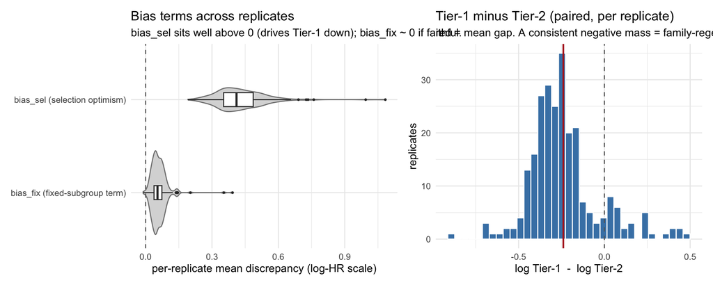

```r
bias_long <- rbind(
  data.frame(term = "bias_sel (selection optimism)", value = cc$bias_sel),
  data.frame(term = "bias_fix (fixed-subgroup term)", value = cc$bias_fix))
p_bias <- ggplot(subset(bias_long, is.finite(value)), aes(term, value)) +
  geom_violin(fill = "grey85", colour = "grey50") +
  geom_boxplot(width = 0.15, outlier.size = 0.6) +
  geom_hline(yintercept = 0, linetype = 2, colour = "grey40") +
  coord_flip() +
  labs(x = NULL, y = "per-replicate mean discrepancy (log-HR scale)",
       title = "Bias terms across replicates",
       subtitle = "bias_sel sits well above 0 (drives Tier-1 down); bias_fix ~ 0 if faithful.") +
  theme_minimal(base_size = 11)

p_gap <- ggplot(subset(cc, is.finite(gap_log)), aes(gap_log)) +
  geom_histogram(bins = 35, fill = "steelblue", colour = "white") +
  geom_vline(xintercept = 0, linetype = 2, colour = "grey40") +
  geom_vline(xintercept = mean(cc$gap_log, na.rm = TRUE), colour = "firebrick", linewidth = 0.8) +
  labs(x = "log Tier-1  -  log Tier-2", y = "replicates",
       title = "Tier-1 minus Tier-2 (paired, per replicate)",
       subtitle = "red = mean gap. A consistent negative mass = family-regeneration; a few extreme reps = outlier-driven.") +
  theme_minimal(base_size = 11)

if (has_patch) p_bias + p_gap else { print(p_bias); print(p_gap) }
```

## 3.4 Over-extension across replicates

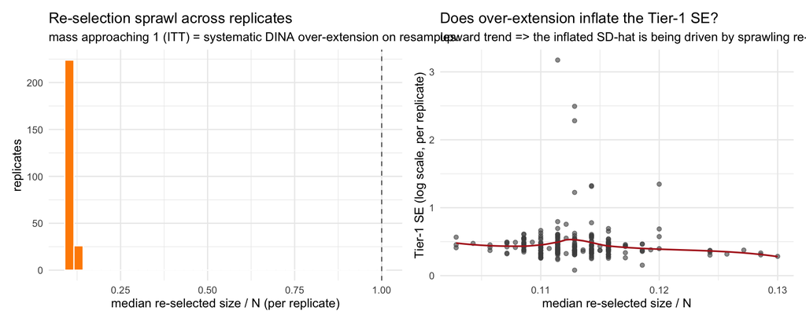

```r
p_oe_hist <- ggplot(subset(cc, is.finite(over_ext)), aes(over_ext)) +
  geom_histogram(bins = 35, fill = "darkorange", colour = "white") +
  geom_vline(xintercept = 1, linetype = 2, colour = "grey40") +
  labs(x = "median re-selected size / N (per replicate)", y = "replicates",
       title = "Re-selection sprawl across replicates",
       subtitle = "mass approaching 1 (ITT) = systematic DINA over-extension on resamples.") +
  theme_minimal(base_size = 11)

p_oe_sd <- ggplot(subset(cc, is.finite(over_ext) & is.finite(sd_log_t1)),
                  aes(over_ext, sd_log_t1)) +
  geom_point(alpha = 0.6, colour = "grey30") +
  geom_smooth(method = "loess", se = FALSE, colour = "firebrick", linewidth = 0.7) +
  labs(x = "median re-selected size / N", y = "Tier-1 SE (log scale, per replicate)",
       title = "Does over-extension inflate the Tier-1 SE?",
       subtitle = "upward trend => the inflated SD-hat is being driven by sprawling re-selections.") +
  theme_minimal(base_size = 11)

if (has_patch) p_oe_hist + p_oe_sd else { print(p_oe_hist); print(p_oe_sd) }
```

```r
r_oe_sd  <- suppressWarnings(cor(cc$over_ext, cc$sd_log_t1, use = "complete.obs"))
r_oe_gap <- suppressWarnings(cor(cc$over_ext, cc$gap_log,   use = "complete.obs"))
cat(sprintf("Correlation over-extension vs Tier-1 SE: %.2f;  vs Tier-1-Tier-2 gap: %.2f\n",
            r_oe_sd, r_oe_gap))
```

```
Correlation over-extension vs Tier-1 SE: -0.05;  vs Tier-1-Tier-2 gap: -0.03
```

## 3.5 Outlier replicates

```r
ob <- cc[order(-sd_log_t1)][seq_len(min(10L, nrow(cc)))]
knitr::kable(
  ob[, .(sim_id, n_sel, med_Nsg, max_Nsg, N_rep,
         t1_HR = round(t1_est, 2), t2_HR = round(t2_est, 2),
         sd_log_t1 = round(sd_log_t1, 3), gap_log = round(gap_log, 3),
         bias_sel = round(bias_sel, 3), n_eval)],
  caption = "Replicates with the largest Tier-1 SE. Large med_Nsg / max_Nsg relative to N_rep marks the over-extended replicates inflating the average SD-hat.")
```

Replicates with the largest Tier-1 SE. Large med_Nsg / max_Nsg relative to N_rep marks the over-extended replicates inflating the average SD-hat.

| sim_id | n_sel | med_Nsg | max_Nsg | N_rep | t1_HR | t2_HR | sd_log_t1 | gap_log | bias_sel | n_eval |
| --- | --- | --- | --- | --- | --- | --- | --- | --- | --- | --- |
| 118 | 70 | 78.0 | 139 | 700 | 0.94 | 1.77 | 3.174 | -0.634 | 0.734 | 324 |
| 121 | 77 | 79.0 | 139 | 700 | 1.87 | 4.57 | 2.493 | -0.892 | 0.586 | 330 |
| 190 | 163 | 79.0 | 172 | 700 | 0.53 | 0.62 | 2.281 | -0.154 | 0.726 | 321 |
| 369 | 87 | 84.0 | 228 | 700 | 1.08 | 2.11 | 1.347 | -0.674 | 0.564 | 335 |
| 53 | 80 | 80.0 | 186 | 700 | 0.65 | 0.87 | 1.325 | -0.288 | 0.760 | 335 |
| 91 | 107 | 80.0 | 159 | 700 | 0.77 | 1.54 | 1.314 | -0.689 | 0.994 | 391 |
| 152 | 102 | 79.0 | 191 | 700 | 0.27 | 0.34 | 1.226 | -0.235 | 1.083 | 245 |
| 124 | 85 | 78.0 | 158 | 700 | 1.28 | 1.94 | 0.796 | -0.419 | 0.548 | 366 |
| 306 | 78 | 80.0 | 176 | 700 | 0.78 | 1.03 | 0.779 | -0.273 | 0.453 | 297 |
| 441 | 71 | 78.5 | 155 | 700 | 0.81 | 0.64 | 0.757 | 0.231 | 0.562 | 340 |

# 4 Reading the diagnostics

A **healthy** family-regeneration gap looks like: `eta*_b(H)` centred near zero, `eta*_b(H*_b)` a moderately right-skewed bulk with mean `bias_sel`, re-selected sizes clustered near the observed Ĥ size (not piling up at ITT N), few IQR-fence outliers, and an IJ-variance curve that rises gradually (no single subject or resample dominating). In that case Tier-1 ≪ Tier-2 and SD̂ > empirical SD are the documented *unconditional vs conditional-on-family* behaviour, not a defect.

For the **cross-replicate** views: a `Ratio` modestly above 1 in the SD-calibration table with oracle coverage at or above nominal is the documented conservatism of the full-bootstrap IJ on a data-driven family (SIM 2024, Table 2) — Tier-1 is the *unconditional* estimator and is expected to run wider than Tier-2. The over- extension panel separates that benign case from a driven one: if the median-re-selected-size/N histogram piles toward 1 and its correlation with the Tier-1 SE is strongly positive, the inflated `Mean_SDhat_HR` is coming from sprawling re-selections on a subset of replicates (visible in the outlier-replicate table as large `med_Nsg`/`max_Nsg` relative to `N_rep`), and the fix is again on the DINA qualification, not the bootstrap. `bias_fix` sitting away from zero across replicates would instead point back at the within-subgroup fit (separation on small re-selected subgroups), which the Finding-2 guard now neutralises.